# final

### Purpose

##### In this tutorial, our aim is to explore whether there is any connection between the day-to-day price changes of 10 S&P500 sector-based ETFs during the past 5 years and the price movements of 10-year bonds, the Euro Index, the US Dollar Index, gold, and crude oil on the same day. Additionally, we will analyze if there are any differences in how these indicators impact each sector. It's crucial to note that we will be looking into short-term price movements, not long-term trends. The importance of this project lies in its potential to help investors mitigate risks in the complex and intertwined world of the market, where they may face significant challenges. Ultimately, this study intends to provide investors with a foundation for identifying suitable risk management strategies and making informed investment decisions.

### Data Collection

##### To start off this tutorial, we'll gather all the required data and organize it into a Pandas DataFrame. The data we'll be working with pertains to daily price changes over a 5-year period. We sourced historical data on S&P 500 sector-based ETFs from Yahoo Finance and obtained historical data on 5 indices from Investing.com. Once the data was collected, we made some adjustments to column names and converted the dates into datetime format.

```python
from bs4 import BeautifulSoup
import pandas as pd
```

```python
df_xly = pd.read_csv('XLY.csv')
df_xlv = pd.read_csv('XLV.csv')
df_xlre = pd.read_csv('XLRE.csv')
df_xlp = pd.read_csv('XLP.csv')
df_xlk = pd.read_csv('XLK.csv')
df_xli = pd.read_csv('XLI.csv')
df_xlf = pd.read_csv('XLF.csv')
df_xle = pd.read_csv('XLE.csv')
df_xlc = pd.read_csv('XLC.csv')
df_xlb = pd.read_csv('XLB.csv')
```

```python
df_xly.head()
```

|  | Date | Open | High | Low | Close | Adj Close | Volume |
| --- | --- | --- | --- | --- | --- | --- | --- |
| 0 | 2018-04-02 | 100.680000 | 100.820000 | 97.480003 | 98.430000 | 93.451813 | 11888300 |
| 1 | 2018-04-03 | 99.010002 | 100.220001 | 98.260002 | 99.680000 | 94.638596 | 7307900 |
| 2 | 2018-04-04 | 98.169998 | 101.709999 | 98.070000 | 101.510002 | 96.376060 | 7442800 |
| 3 | 2018-04-05 | 102.370003 | 103.199997 | 101.800003 | 102.870003 | 97.667267 | 4231500 |
| 4 | 2018-04-06 | 101.879997 | 102.790001 | 100.029999 | 100.680000 | 95.588020 | 8764900 |

```python
df_us_index = pd.read_csv('US Dollar Index Futures Historical Data (1).csv')
df_eur_index = pd.read_csv('Investing.com Euro Index Historical Data.csv')
df_gold = pd.read_csv('XAU_USD Historical Data.csv')
df_bond = pd.read_csv('United States 10-Year Bond Yield Historical Data.csv')
df_oil = pd.read_csv('Crude Oil WTI Futures Historical Data.csv')
```

```python
df_eur_index
```

|  | Date | Price | Open | High | Low | Vol. | Change % |
| --- | --- | --- | --- | --- | --- | --- | --- |
| 0 | 03/31/2023 | 122.06 | 121.24 | 122.50 | 120.92 | NaN | 0.68% |
| 1 | 03/30/2023 | 121.24 | 121.12 | 122.61 | 120.84 | NaN | 0.10% |
| 2 | 03/29/2023 | 121.12 | 121.13 | 122.04 | 120.93 | NaN | -0.01% |
| 3 | 03/28/2023 | 121.13 | 121.13 | 121.68 | 120.82 | NaN | 0.00% |
| 4 | 03/27/2023 | 121.12 | 121.07 | 121.33 | 120.78 | NaN | 0.04% |
| ... | ... | ... | ... | ... | ... | ... | ... |
| 1568 | 04/05/2018 | 96.67 | 96.82 | 96.84 | 96.53 | NaN | -0.15% |
| 1569 | 04/04/2018 | 96.82 | 96.72 | 96.94 | 96.59 | NaN | 0.10% |
| 1570 | 04/03/2018 | 96.72 | 96.81 | 97.09 | 96.56 | NaN | -0.08% |
| 1571 | 04/02/2018 | 96.80 | 96.98 | 97.16 | 96.74 | NaN | -0.19% |
| 1572 | 04/01/2018 | 96.98 | 97.03 | 97.15 | 96.97 | NaN | -0.05% |

1573 rows × 7 columns

```python
df_us_index
```

|  | Date | Price | Open | High | Low | Vol. | Change % |
| --- | --- | --- | --- | --- | --- | --- | --- |
| 0 | Mar 31, 2023 | 102.186 | 101.905 | 102.305 | 101.730 | 12.30K | 0.36% |
| 1 | Mar 30, 2023 | 101.821 | 102.305 | 102.460 | 101.750 | 8.87K | -0.47% |
| 2 | Mar 29, 2023 | 102.298 | 102.130 | 102.440 | 102.030 | 10.00K | 0.19% |
| 3 | Mar 28, 2023 | 102.106 | 102.425 | 102.430 | 102.040 | 9.38K | -0.40% |
| 4 | Mar 27, 2023 | 102.518 | 102.770 | 102.895 | 102.480 | 7.36K | -0.24% |
| ... | ... | ... | ... | ... | ... | ... | ... |
| 1288 | Apr 06, 2018 | 89.357 | 89.655 | 89.780 | 89.330 | 0.10K | -0.40% |
| 1289 | Apr 05, 2018 | 89.719 | 89.385 | 89.815 | 89.370 | 0.10K | 0.40% |
| 1290 | Apr 04, 2018 | 89.358 | 89.380 | 89.445 | 89.150 | 0.05K | -0.09% |
| 1291 | Apr 03, 2018 | 89.439 | 89.295 | 89.535 | 89.295 | 0.03K | 0.17% |
| 1292 | Apr 02, 2018 | 89.291 | 89.160 | 89.380 | 89.125 | 0.03K | -0.11% |

1293 rows × 7 columns

```python
df_gold
```

|  | Date | Price | Open | High | Low | Vol. | Change % |
| --- | --- | --- | --- | --- | --- | --- | --- |
| 0 | 03/31/2023 | 1,967.90 | 1,978.62 | 1,987.84 | 1,966.89 | NaN | -0.62% |
| 1 | 03/30/2023 | 1,980.25 | 1,962.58 | 1,984.40 | 1,955.44 | NaN | 0.83% |
| 2 | 03/29/2023 | 1,964.04 | 1,972.82 | 1,974.64 | 1,958.62 | NaN | -0.49% |
| 3 | 03/28/2023 | 1,973.69 | 1,957.23 | 1,975.45 | 1,948.66 | NaN | 0.88% |
| 4 | 03/27/2023 | 1,956.56 | 1,977.66 | 1,979.89 | 1,943.68 | NaN | -1.04% |
| ... | ... | ... | ... | ... | ... | ... | ... |
| 1298 | 04/06/2018 | 1,333.20 | 1,326.38 | 1,335.59 | 1,321.47 | NaN | 0.50% |
| 1299 | 04/05/2018 | 1,326.55 | 1,333.02 | 1,335.29 | 1,322.80 | NaN | -0.51% |
| 1300 | 04/04/2018 | 1,333.35 | 1,332.82 | 1,348.45 | 1,331.59 | NaN | 0.04% |
| 1301 | 04/03/2018 | 1,332.83 | 1,340.69 | 1,342.87 | 1,329.18 | NaN | -0.64% |
| 1302 | 04/02/2018 | 1,341.35 | 1,326.20 | 1,345.26 | 1,324.90 | NaN | 1.23% |

1303 rows × 7 columns

```python
df_bond
```

|  | Date | Price | Open | High | Low | Change % |
| --- | --- | --- | --- | --- | --- | --- |
| 0 | 03/31/2023 | 3.473 | 3.553 | 3.585 | 3.470 | -2.08% |
| 1 | 03/30/2023 | 3.547 | 3.570 | 3.596 | 3.534 | -0.53% |
| 2 | 03/29/2023 | 3.566 | 3.573 | 3.611 | 3.534 | -0.16% |
| 3 | 03/28/2023 | 3.572 | 3.530 | 3.577 | 3.498 | 0.91% |
| 4 | 03/27/2023 | 3.539 | 3.400 | 3.545 | 3.367 | 4.95% |
| ... | ... | ... | ... | ... | ... | ... |
| 1292 | 04/06/2018 | 2.775 | 2.817 | 2.830 | 2.768 | -2.06% |
| 1293 | 04/05/2018 | 2.834 | 2.808 | 2.838 | 2.805 | 0.91% |
| 1294 | 04/04/2018 | 2.808 | 2.773 | 2.810 | 2.748 | 0.99% |
| 1295 | 04/03/2018 | 2.781 | 2.737 | 2.790 | 2.735 | 1.73% |
| 1296 | 04/02/2018 | 2.733 | 2.759 | 2.773 | 2.717 | -0.27% |

1297 rows × 6 columns

```python
df_oil
```

|  | Date | Price | Open | High | Low | Vol. | Change % |
| --- | --- | --- | --- | --- | --- | --- | --- |
| 0 | 03/31/2023 | 75.67 | 74.37 | 75.72 | 73.77 | 304.36K | 1.75% |
| 1 | 03/30/2023 | 74.37 | 72.98 | 74.63 | 72.61 | 269.74K | 1.92% |
| 2 | 03/29/2023 | 72.97 | 73.61 | 74.37 | 72.76 | 312.67K | -0.31% |
| 3 | 03/28/2023 | 73.20 | 72.86 | 73.93 | 72.19 | 328.47K | 0.54% |
| 4 | 03/27/2023 | 72.81 | 69.42 | 73.10 | 69.13 | 353.60K | 5.13% |
| ... | ... | ... | ... | ... | ... | ... | ... |
| 1318 | 04/06/2018 | 62.06 | 63.70 | 63.79 | 61.81 | 753.26K | -2.33% |
| 1319 | 04/05/2018 | 63.54 | 63.60 | 64.12 | 63.07 | 588.60K | 0.27% |
| 1320 | 04/04/2018 | 63.37 | 63.59 | 63.64 | 62.06 | 760.60K | -0.22% |
| 1321 | 04/03/2018 | 63.51 | 62.89 | 63.86 | 62.86 | 527.29K | 0.79% |
| 1322 | 04/02/2018 | 63.01 | 64.91 | 65.42 | 62.80 | 582.74K | -2.97% |

1323 rows × 7 columns

```python
df_oil = df_oil.rename(columns={'Date': 'Date',
                                'Price': 'Oil Closing',
                                'Open': 'Oil Open',
                                'High': 'Oil High',
                                'Low': 'Oil Low',
                                'Vol.': 'Oil Vol',
                                'Change %': 'Oil Change %'})
```

```python
df_gold = df_gold.rename(columns={'Date': 'Date',
                                'Price': 'Gold Closing',
                                'Open': 'Gold Open',
                                'High': 'Gold High',
                                'Low': 'Gold Low',
                                'Vol.': 'Gold Vol',
                                'Change %': 'Gold Change %'})
```

```python
df_us_index = df_us_index.rename(columns={'Date': 'Date',
                                'Price': 'USD Index Closing',
                                'Open': 'USD Index Open',
                                'High': 'USD Index High',
                                'Low': 'USD Index Low',
                                'Vol.': 'USD Index Vol',
                                'Change %': 'USD Index Change %'})
```

```python
df_eur_index = df_eur_index.rename(columns={'Date': 'Date',
                                'Price': 'EUR Index Closing',
                                'Open': 'EUR Index Open',
                                'High': 'EUR Index High',
                                'Low': 'EUR Index Low',
                                'Vol.': 'EUR Index Vol',
                                'Change %': 'EUR Index Change %'})
```

```python
df_bond = df_bond.rename(columns={'Date': 'Date',
                                'Price': 'T-bonds Closing',
                                'Open': 'T-bonds Open',
                                'High': 'T-bonds High',
                                'Low': 'T-bonds Low',
                                'Change %': 'T-bonds Change %'})
```

```python
df_oil.head()
```

|  | Date | Oil Closing | Oil Open | Oil High | Oil Low | Oil Vol | Oil Change % |
| --- | --- | --- | --- | --- | --- | --- | --- |
| 0 | 03/31/2023 | 75.67 | 74.37 | 75.72 | 73.77 | 304.36K | 1.75% |
| 1 | 03/30/2023 | 74.37 | 72.98 | 74.63 | 72.61 | 269.74K | 1.92% |
| 2 | 03/29/2023 | 72.97 | 73.61 | 74.37 | 72.76 | 312.67K | -0.31% |
| 3 | 03/28/2023 | 73.20 | 72.86 | 73.93 | 72.19 | 328.47K | 0.54% |
| 4 | 03/27/2023 | 72.81 | 69.42 | 73.10 | 69.13 | 353.60K | 5.13% |

```python
df_oil['Date'] = pd.to_datetime(df_oil['Date'], format='%m/%d/%Y')
df_bond['Date'] = pd.to_datetime(df_bond['Date'], format='%m/%d/%Y')
df_eur_index['Date'] = pd.to_datetime(df_eur_index['Date'], format='%m/%d/%Y')
df_us_index['Date'] = pd.to_datetime(df_us_index['Date'], format='%b %d, %Y')
df_gold['Date'] = pd.to_datetime(df_gold['Date'], format='%m/%d/%Y')
```

### Data Processing and Exploratory Data Analysis

##### To better understand the data structure and build an optimal model, we'll preprocess the data next. Initially, we'll use df.shape to check the volume of data for each index, followed by using df.info() to assess the data quality. Evaluating the data quality involves examining the specific data type and identifying missing values for each index.

```python
df_us_index.shape
```

```
(1293, 7)
```

```python
df_gold.shape
```

```
(1303, 7)
```

```python
df_eur_index.shape
```

```
(1573, 7)
```

```python
df_bond.shape
```

```
(1297, 6)
```

```python
df_oil.shape
```

```
(1323, 7)
```

```python
df_us_index.info()
```

```
<class 'pandas.core.frame.DataFrame'>
RangeIndex: 1293 entries, 0 to 1292
Data columns (total 7 columns):
 #   Column              Non-Null Count  Dtype
---  ------              --------------  -----
 0   Date                1293 non-null   datetime64[ns]
 1   USD Index Closing   1293 non-null   float64
 2   USD Index Open      1293 non-null   float64
 3   USD Index High      1293 non-null   float64
 4   USD Index Low       1293 non-null   float64
 5   USD Index Vol       1293 non-null   object
 6   USD Index Change %  1293 non-null   object
dtypes: datetime64[ns](1), float64(4), object(2)
memory usage: 70.8+ KB
```

##### It can be seen that all columns of df_us_index, which has 1293 rows, have a Non-Null Count of 1293, so it can be concluded that df_us_index does not have any missing values.

```python
df_gold.info()
```

```
<class 'pandas.core.frame.DataFrame'>
RangeIndex: 1303 entries, 0 to 1302
Data columns (total 7 columns):
 #   Column         Non-Null Count  Dtype
---  ------         --------------  -----
 0   Date           1303 non-null   datetime64[ns]
 1   Gold Closing   1303 non-null   object
 2   Gold Open      1303 non-null   object
 3   Gold High      1303 non-null   object
 4   Gold Low       1303 non-null   object
 5   Gold Vol       0 non-null      float64
 6   Gold Change %  1303 non-null   object
dtypes: datetime64[ns](1), float64(1), object(5)
memory usage: 71.4+ KB
```

##### It can be seen that all columns except Gold Vol of df_gold, which has 1303 rows, have a Non-Null Count of 1303, so it can be concluded that df_us_index does not have any missing values except in the Gold Vol column.

```python
df_eur_index.info()
```

```
<class 'pandas.core.frame.DataFrame'>
RangeIndex: 1573 entries, 0 to 1572
Data columns (total 7 columns):
 #   Column              Non-Null Count  Dtype
---  ------              --------------  -----
 0   Date                1573 non-null   datetime64[ns]
 1   EUR Index Closing   1573 non-null   float64
 2   EUR Index Open      1573 non-null   float64
 3   EUR Index High      1573 non-null   float64
 4   EUR Index Low       1573 non-null   float64
 5   EUR Index Vol       0 non-null      float64
 6   EUR Index Change %  1573 non-null   object
dtypes: datetime64[ns](1), float64(5), object(1)
memory usage: 86.1+ KB
```

##### It can be seen that all columns except EUR Index Vol of df_eur_index, which has 1573 rows, have a Non-Null Count of 1573, so it can be concluded that df_eur_index does not have any missing values except in the EUR Index Vol column.

```python
df_oil.info()
```

```
<class 'pandas.core.frame.DataFrame'>
RangeIndex: 1323 entries, 0 to 1322
Data columns (total 7 columns):
 #   Column        Non-Null Count  Dtype
---  ------        --------------  -----
 0   Date          1323 non-null   datetime64[ns]
 1   Oil Closing   1323 non-null   float64
 2   Oil Open      1323 non-null   float64
 3   Oil High      1323 non-null   float64
 4   Oil Low       1323 non-null   float64
 5   Oil Vol       1239 non-null   object
 6   Oil Change %  1323 non-null   object
dtypes: datetime64[ns](1), float64(4), object(2)
memory usage: 72.5+ KB
```

##### It can be seen that all columns except Oil Vol of df_oil, which has 1323 rows, have a Non-Null Count of 1323, so it can be concluded that df_oil does not have any missing values except in the Oil Vol column.

```python
df_bond.info()
```

```
<class 'pandas.core.frame.DataFrame'>
RangeIndex: 1297 entries, 0 to 1296
Data columns (total 6 columns):
 #   Column            Non-Null Count  Dtype
---  ------            --------------  -----
 0   Date              1297 non-null   datetime64[ns]
 1   T-bonds Closing   1297 non-null   float64
 2   T-bonds Open      1297 non-null   float64
 3   T-bonds High      1297 non-null   float64
 4   T-bonds Low       1297 non-null   float64
 5   T-bonds Change %  1297 non-null   object
dtypes: datetime64[ns](1), float64(4), object(1)
memory usage: 60.9+ KB
```

##### It can be seen that all columns of df_us_index, which has 1297 rows, have a Non-Null Count of 1297, so it can be concluded that df_us_index does not have any missing values.

##### As you can see, the "Change %" column in all of the dataframes has a data type of "object" because the elements in this column are in the format of "float%". To proceed with our analysis, we need to remove the "%" symbol and convert these values into the "float64" data type.

```python
df_oil['Oil Change %'] = df_oil['Oil Change %'].str.rstrip('%').astype('float64') / 100.0
df_eur_index['EUR Index Change %'] = df_eur_index['EUR Index Change %'].str.rstrip('%').astype('float64') / 100.0
df_us_index['USD Index Change %'] = df_us_index['USD Index Change %'].str.rstrip('%').astype('float64') / 100.0
df_gold['Gold Change %'] = df_gold['Gold Change %'].str.rstrip('%').astype('float64') / 100.0
df_bond['T-bonds Change %'] = df_bond['T-bonds Change %'].str.rstrip('%').astype('float64') / 100.0
```

##### In the next step, we will examine basic statistics for each index, such as the mean, maximum, and minimum daily change percentages, to gain a better understanding of the data. The describe function allows us to quickly obtain simple statistics, such as the maximum, minimum, mean, and top 25 percent. We will use the Matplotlib data visualization library to create a histogram to examine how much data is concentrated around specific daily change percentages.

```python
df_oil['Oil Change %'].describe()
```

```
count    1323.000000
mean       -0.002146
std         0.097039
min        -3.059700
25%        -0.012000
50%         0.002200
75%         0.014200
max         0.376600
Name: Oil Change %, dtype: float64
```

```python
import matplotlib.pyplot as plt
```

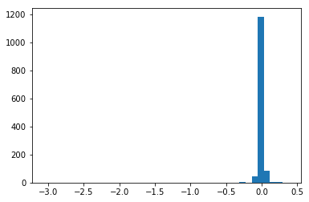

```python
plt.hist(df_oil['Oil Change %'], bins=40, range=(-3.059700,0.376600))
```

```python
df_gold['Gold Change %'].describe()
```

```
count    1303.000000
mean        0.000344
std         0.008980
min        -0.057300
25%        -0.004100
50%         0.000600
75%         0.005150
max         0.043900
Name: Gold Change %, dtype: float64
```

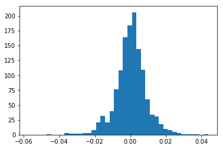

```python
plt.hist(df_gold['Gold Change %'], bins=40, range=(-0.057300,0.043900))
```

```python
df_us_index['USD Index Change %'].describe()
```

```
count    1293.000000
mean        0.000113
std         0.004300
min        -0.021400
25%        -0.002300
50%         0.000000
75%         0.002400
max         0.021200
Name: USD Index Change %, dtype: float64
```

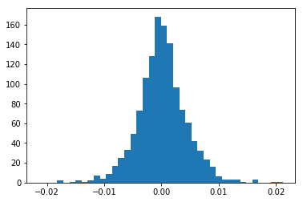

```python
plt.hist(df_us_index['USD Index Change %'], bins=40, range=(-0.021400,0.021200))
```

```python
df_eur_index['EUR Index Change %'].describe()
```

```
count    1573.000000
mean        0.000149
std         0.002756
min        -0.030100
25%         0.000000
50%         0.000300
75%         0.000600
max         0.022900
Name: EUR Index Change %, dtype: float64
```

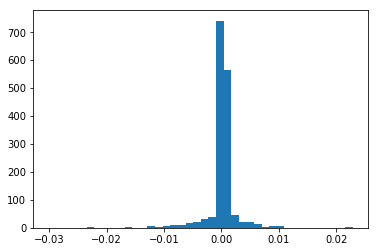

```python
plt.hist(df_eur_index['EUR Index Change %'], bins=40, range=(-0.030100,0.022900))
```

```python
df_bond['T-bonds Change %'].describe()
```

```
count    1297.000000
mean        0.000914
std         0.038677
min        -0.276700
25%        -0.015600
50%         0.000600
75%         0.015800
max         0.443700
Name: T-bonds Change %, dtype: float64
```

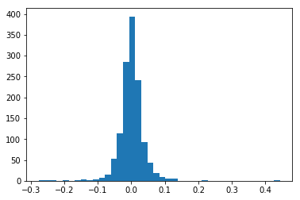

```python
plt.hist(df_bond['T-bonds Change %'], bins=40, range=(-0.276700,0.443700))
```

```python
import numpy as np
```

```python
z_scores = np.abs((df_oil['Oil Change %'] - df_oil['Oil Change %'].mean()) / df_oil['Oil Change %'].std())

# Set a threshold for outlier detection
threshold = 3

# Find outliers
outliers = df_oil['Oil Change %'][z_scores > threshold]

# Remove outliers
df_oil = df_oil.drop(outliers.index)
```

```python
df_oil['Oil Change %'].describe()
```

```
count    1320.000000
mean        0.000841
std         0.031964
min        -0.245900
25%        -0.011900
50%         0.002200
75%         0.014200
max         0.251000
Name: Oil Change %, dtype: float64
```

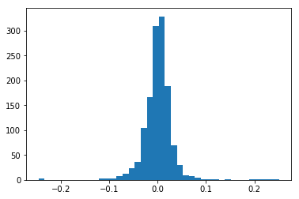

```python
plt.hist(df_oil['Oil Change %'], bins=40, range=(-0.245900,0.251000))
```

```python
z_scores = np.abs((df_eur_index['EUR Index Change %'] - df_eur_index['EUR Index Change %'].mean()) / df_eur_index['EUR Index Change %'].std())

# Set a threshold for outlier detection
threshold = 3

# Find outliers
outliers = df_eur_index['EUR Index Change %'][z_scores > threshold]

# Remove outliers
df_eur_index = df_eur_index.drop(outliers.index)
```

```python
df_eur_index['EUR Index Change %'].describe()
```

```
count    1528.000000
mean        0.000251
std         0.001588
min        -0.007700
25%         0.000000
50%         0.000300
75%         0.000600
max         0.008400
Name: EUR Index Change %, dtype: float64
```

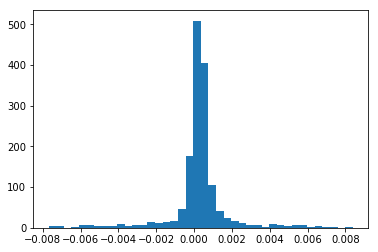

```python
plt.hist(df_eur_index['EUR Index Change %'], bins=40, range=(-0.007700,0.008400))
```

```python
z_scores = np.abs((df_bond['T-bonds Change %'] - df_bond['T-bonds Change %'].mean()) / df_bond['T-bonds Change %'].std())

# Set a threshold for outlier detection
threshold = 3

# Find outliers
outliers = df_bond['T-bonds Change %'][z_scores > threshold]

# Remove outliers
df_bond = df_bond.drop(outliers.index)
```

```python
df_bond['T-bonds Change %'].describe()
```

```
count    1279.000000
mean        0.000997
std         0.028996
min        -0.106200
25%        -0.015050
50%         0.000600
75%         0.015800
max         0.115200
Name: T-bonds Change %, dtype: float64
```

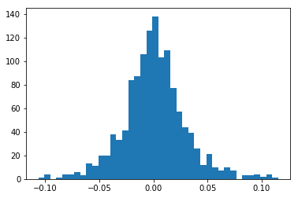

```python
plt.hist(df_bond['T-bonds Change %'], bins=40, range=(-0.106200,0.115200))
```

```python
z_scores = np.abs((df_us_index['USD Index Change %'] - df_us_index['USD Index Change %'].mean()) / df_us_index['USD Index Change %'].std())

# Set a threshold for outlier detection
threshold = 3

# Find outliers
outliers = df_us_index['USD Index Change %'][z_scores > threshold]

# Remove outliers
df_us_index = df_us_index.drop(outliers.index)
```

```python
df_us_index['USD Index Change %'].describe()
```

```
count    1278.000000
mean        0.000103
std         0.003934
min        -0.012300
25%        -0.002300
50%         0.000000
75%         0.002400
max         0.012800
Name: USD Index Change %, dtype: float64
```

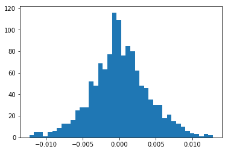

```python
plt.hist(df_us_index['USD Index Change %'], bins=40, range=(-0.012300,0.012800))
```

```python
z_scores = np.abs((df_gold['Gold Change %'] - df_gold['Gold Change %'].mean()) / df_gold['Gold Change %'].std())

# Set a threshold for outlier detection
threshold = 3

# Find outliers
outliers = df_gold['Gold Change %'][z_scores > threshold]

# Remove outliers
df_gold = df_gold.drop(outliers.index)
```

```python
df_gold['Gold Change %'].describe()
```

```
count    1285.00000
mean        0.00047
std         0.00800
min        -0.02510
25%        -0.00390
50%         0.00070
75%         0.00510
max         0.02720
Name: Gold Change %, dtype: float64
```

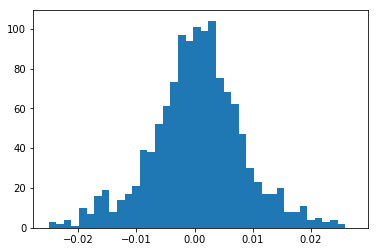

```python
plt.hist(df_gold['Gold Change %'], bins=40, range=(-0.02510,0.02720))
```

##### Next, we will remove the "Vol." column from all five dataframes. While trading volume is an important indicator for measuring market sentiment in commodities, indexes, stocks, and other trading assets, the available volume data in this dataframe is sourced only from Investing.com, which may not provide accurate volume information due to variations across different exchanges. Therefore, it is necessary to exclude this column from our analysis.

```python
df_oil = df_oil.drop(columns=['Oil Vol'])
```

```python
df_us_index = df_us_index.drop(columns=['USD Index Vol'])
df_eur_index = df_eur_index.drop(columns=['EUR Index Vol'])
df_gold = df_gold.drop(columns=['Gold Vol'])
```

##### In the same vein, we will remove the "High" and "Low" columns from all five dataframes. As this analysis focuses only on the price range between the opening and closing times of the market, the daily high and low prices are not relevant. While these are important factors for a more precise analysis of price movements, hourly data for the S&P500 sectors and these five indicators is not available. Therefore, the best possible analysis is to observe the difference between the opening and closing prices.

```python
df_oil = df_oil.drop(columns=['Oil Open'])
df_us_index = df_us_index.drop(columns=['USD Index Open'])
df_eur_index = df_eur_index.drop(columns=['EUR Index Open'])
df_gold = df_gold.drop(columns=['Gold Open'])
df_bond = df_bond.drop(columns=['T-bonds Open'])

df_oil = df_oil.drop(columns=['Oil Closing'])
df_us_index = df_us_index.drop(columns=['USD Index Closing'])
df_eur_index = df_eur_index.drop(columns=['EUR Index Closing'])
df_gold = df_gold.drop(columns=['Gold Closing'])
df_bond = df_bond.drop(columns=['T-bonds Closing'])

df_oil = df_oil.drop(columns=['Oil High'])
df_us_index = df_us_index.drop(columns=['USD Index High'])
df_eur_index = df_eur_index.drop(columns=['EUR Index High'])
df_gold = df_gold.drop(columns=['Gold High'])
df_bond = df_bond.drop(columns=['T-bonds High'])

df_oil = df_oil.drop(columns=['Oil Low'])
df_us_index = df_us_index.drop(columns=['USD Index Low'])
df_eur_index = df_eur_index.drop(columns=['EUR Index Low'])
df_gold = df_gold.drop(columns=['Gold Low'])
df_bond = df_bond.drop(columns=['T-bonds Low'])
```

```python
df_indices = df_oil.merge(df_gold, on='Date', how='inner') \
                  .merge(df_bond, on='Date', how='inner') \
                  .merge(df_us_index, on='Date', how='inner') \
                  .merge(df_eur_index, on='Date', how='inner')

df_indices.dropna(inplace=True)
```

```python
df_indices
```

|  | Date | Oil Change % | Gold Change % | T-bonds Change % | USD Index Change % | EUR Index Change % |
| --- | --- | --- | --- | --- | --- | --- |
| 0 | 2023-03-31 | 0.0175 | -0.0062 | -0.0208 | 0.0036 | 0.0068 |
| 1 | 2023-03-30 | 0.0192 | 0.0083 | -0.0053 | -0.0047 | 0.0010 |
| 2 | 2023-03-29 | -0.0031 | -0.0049 | -0.0016 | 0.0019 | -0.0001 |
| 3 | 2023-03-28 | 0.0054 | 0.0088 | 0.0091 | -0.0040 | 0.0000 |
| 4 | 2023-03-27 | 0.0513 | -0.0104 | 0.0495 | -0.0024 | 0.0004 |
| ... | ... | ... | ... | ... | ... | ... |
| 1202 | 2018-04-06 | -0.0233 | 0.0050 | -0.0206 | -0.0040 | 0.0012 |
| 1203 | 2018-04-05 | 0.0027 | -0.0051 | 0.0091 | 0.0040 | -0.0015 |
| 1204 | 2018-04-04 | -0.0022 | 0.0004 | 0.0099 | -0.0009 | 0.0010 |
| 1205 | 2018-04-03 | 0.0079 | -0.0064 | 0.0173 | 0.0017 | -0.0008 |
| 1206 | 2018-04-02 | -0.0297 | 0.0123 | -0.0027 | -0.0011 | -0.0019 |

1207 rows × 6 columns

##### The above dataframe represents the change in value for five indices on the same date. To conduct a more accurate analysis, any days with missing data in at least one of the five indices have been removed. Therefore, it is important to confirm again that there are no missing values.

```python
df_indices.info()
```

```
<class 'pandas.core.frame.DataFrame'>
Int64Index: 1207 entries, 0 to 1206
Data columns (total 6 columns):
 #   Column              Non-Null Count  Dtype
---  ------              --------------  -----
 0   Date                1207 non-null   datetime64[ns]
 1   Oil Change %        1207 non-null   float64
 2   Gold Change %       1207 non-null   float64
 3   T-bonds Change %    1207 non-null   float64
 4   USD Index Change %  1207 non-null   float64
 5   EUR Index Change %  1207 non-null   float64
dtypes: datetime64[ns](1), float64(5)
memory usage: 66.0 KB
```

##### As you can see, there is no missing data in this dataframe

```python
df_list = [df_xly, df_xlv, df_xlre, df_xlp, df_xlk, df_xli, df_xlf, df_xle, df_xlc, df_xlb]
```

```python
for df in df_list:
    df["Date"] = pd.to_datetime(df["Date"])
```

```python
df_xlb
```

|  | Date | Open | High | Low | Close | Adj Close | Volume |
| --- | --- | --- | --- | --- | --- | --- | --- |
| 0 | 2018-04-02 | 56.750000 | 57.029999 | 55.209999 | 55.700001 | 50.221287 | 9329400 |
| 1 | 2018-04-03 | 55.830002 | 56.650002 | 55.480000 | 56.490002 | 50.933590 | 6786400 |
| 2 | 2018-04-04 | 55.549999 | 56.910000 | 55.230000 | 56.860001 | 51.267200 | 6436700 |
| 3 | 2018-04-05 | 57.130001 | 58.119999 | 57.040001 | 57.919998 | 52.222927 | 7694300 |
| 4 | 2018-04-06 | 57.349998 | 57.619999 | 56.150002 | 56.509998 | 50.951607 | 7911400 |
| ... | ... | ... | ... | ... | ... | ... | ... |
| 1255 | 2023-03-27 | 77.610001 | 77.930000 | 76.820000 | 77.379997 | 77.379997 | 5307000 |
| 1256 | 2023-03-28 | 77.370003 | 77.879997 | 77.290001 | 77.750000 | 77.750000 | 5124000 |
| 1257 | 2023-03-29 | 78.750000 | 78.879997 | 78.480003 | 78.830002 | 78.830002 | 4135100 |
| 1258 | 2023-03-30 | 79.650002 | 79.699997 | 79.080002 | 79.370003 | 79.370003 | 4216700 |
| 1259 | 2023-03-31 | 79.379997 | 80.699997 | 79.379997 | 80.660004 | 80.660004 | 6763100 |

1260 rows × 7 columns

##### Next, we will use Matplotlib to create a line chart that shows the price movements of the 10 S&P 500 sector ETFs. This will help us to identify their similarities and differences. Moreover, although it is not directly related to the topic of this tutorial, it will also enable us to gain a rough understanding of the trend over the past five years.

[output not shown]

[output cut: 21 more lines]

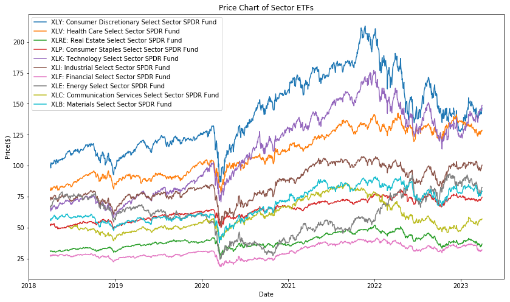

```python
fig, ax = plt.subplots(figsize=(14,8))

ax.plot(df_xly['Date'], df_xly['Open'], label='XLY: Consumer Discretionary Select Sector SPDR Fund')
ax.plot(df_xlv['Date'], df_xlv['Open'], label='XLV: Health Care Select Sector SPDR Fund')
ax.plot(df_xlre['Date'], df_xlre['Open'], label='XLRE: Real Estate Select Sector SPDR Fund')
ax.plot(df_xlp['Date'], df_xlp['Open'], label='XLP: Consumer Staples Select Sector SPDR Fund')
ax.plot(df_xlk['Date'], df_xlk['Open'], label='XLK: Technology Select Sector SPDR Fund')
ax.plot(df_xli['Date'], df_xli['Open'], label='XLI: Industrial Select Sector SPDR Fund')
ax.plot(df_xlf['Date'], df_xlf['Open'], label='XLF: Financial Select Sector SPDR Fund')
ax.plot(df_xle['Date'], df_xle['Open'], label='XLE: Energy Select Sector SPDR Fund')
ax.plot(df_xlc['Date'], df_xlc['Open'], label='XLC: Communication Services Select Sector SPDR Fund')
ax.plot(df_xlb['Date'], df_xlb['Open'], label='XLB: Materials Select Sector SPDR Fund')

ax.legend()
ax.set_xlabel('Date')
ax.set_ylabel('Price($)')
ax.set_title('Price Chart of Sector ETFs')

plt.show()
```

##### The chart above shows the price movements of all the 10 sector ETFs over the past 5 years. Although they may appear similar when viewed over a long period, a closer examination reveals that they are actually quite distinct. Even during periods of general growth, one ETF may experience a significantly larger price movement than others, and there may be instances when they move in different directions. As a result, it's crucial to analyze the price movements separately for each sector, as they exhibit unique patterns of movement.

##### We will create a chart that displays both the price movements and trading volumes of each sector ETF over the past 5 years. Trading volume represents the transaction fees and serves as a measure of market overheating. By examining trading volume together with price movements, we can identify the timing when traders are most active and the corresponding price movements.

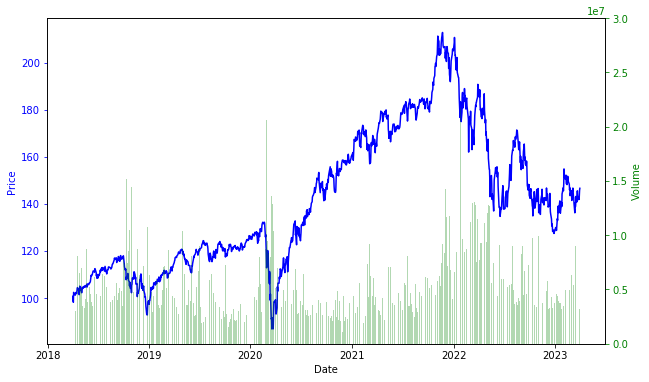

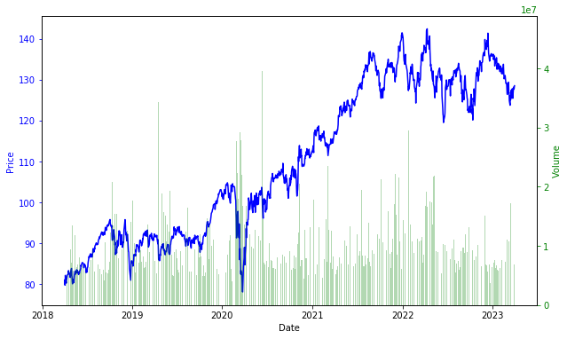

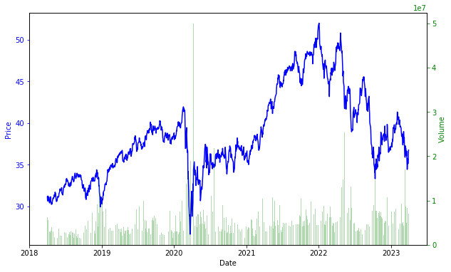

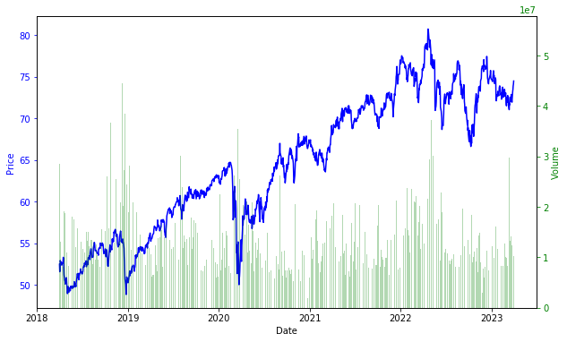

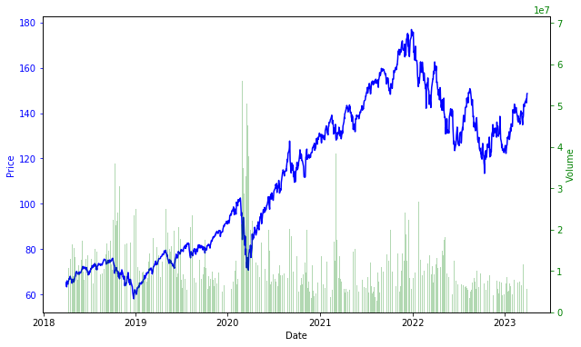

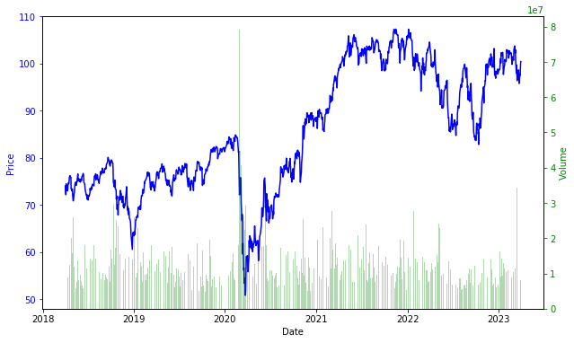

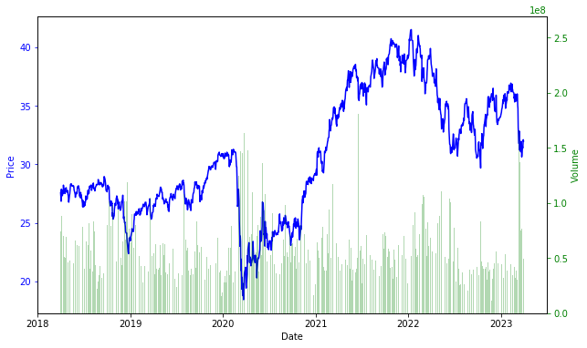

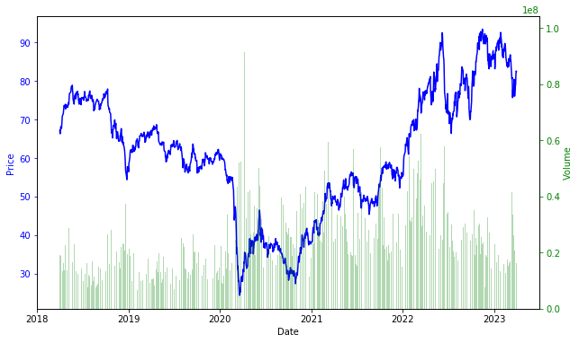

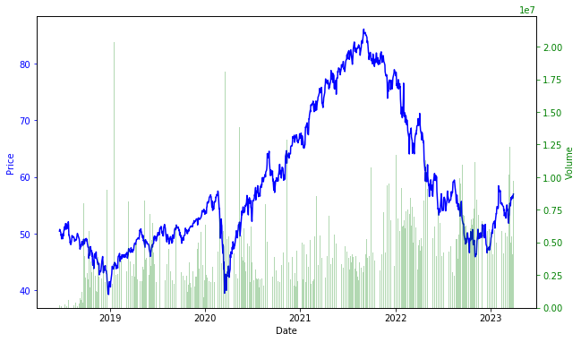

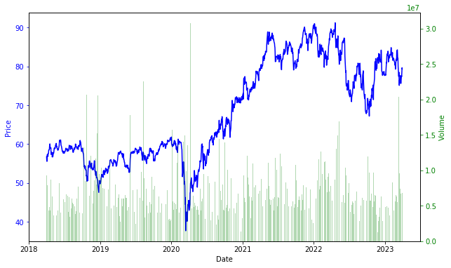

```python
for df in df_list:
    fig, ax1 = plt.subplots(figsize=(10,6))

    ax1.plot(df['Date'], df['Open'], color='b')
    ax1.set_xlabel('Date')
    ax1.set_ylabel('Price', color='b')
    ax1.tick_params('y', colors='b')

    ax2 = ax1.twinx()
    ax2.bar(df['Date'], df['Volume'], color='g', alpha=0.3)
    ax2.set_ylabel('Volume', color='g')
    ax2.tick_params('y', colors='g')

    plt.show()
```

##### The above are charts that combine price movements and volume for each. We can see that although they appear similar at first glance, they have quite different price movements and volumes.

##### We will calculate the daily percentage change for all 10 sector ETFs using the opening and closing prices. While a more precise analysis would consider the high and low prices during the day, obtaining a dataset with such detailed price movements requires a finer granularity. As we could not obtain such data in this case, we will measure the percentage of increase or decrease by comparing the opening and closing prices of the day.

```python
for df in df_list:
    df['Change'] = (df['Close'] - df['Open'])/df['Open']
```

```python
df_xli.head()
```

|  | Date | Open | High | Low | Close | Adj Close | Volume | Change |
| --- | --- | --- | --- | --- | --- | --- | --- | --- |
| 0 | 2018-04-02 | 74.070000 | 74.199997 | 71.779999 | 72.760002 | 66.495110 | 27498800 | -0.017686 |
| 1 | 2018-04-03 | 73.129997 | 73.820000 | 72.629997 | 73.769997 | 67.418167 | 20149100 | 0.008752 |
| 2 | 2018-04-04 | 72.190002 | 74.169998 | 72.010002 | 74.089996 | 67.710625 | 19987600 | 0.026319 |
| 3 | 2018-04-05 | 74.500000 | 75.019997 | 74.279999 | 74.839996 | 68.396034 | 16496100 | 0.004564 |
| 4 | 2018-04-06 | 74.099998 | 74.550003 | 72.110001 | 72.769997 | 66.504265 | 18353400 | -0.017949 |

```python
for df in df_list:
    df.info()
```

```
<class 'pandas.core.frame.DataFrame'>
RangeIndex: 1260 entries, 0 to 1259
Data columns (total 8 columns):
 #   Column     Non-Null Count  Dtype
---  ------     --------------  -----
 0   Date       1260 non-null   datetime64[ns]
 1   Open       1260 non-null   float64
 2   High       1260 non-null   float64
 3   Low        1260 non-null   float64
 4   Close      1260 non-null   float64
 5   Adj Close  1260 non-null   float64
 6   Volume     1260 non-null   int64
 7   Change     1260 non-null   float64
dtypes: datetime64[ns](1), float64(6), int64(1)
memory usage: 78.9 KB
<class 'pandas.core.frame.DataFrame'>
RangeIndex: 1260 entries, 0 to 1259
Data columns (total 8 columns):
 #   Column     Non-Null Count  Dtype
---  ------     --------------  -----
 0   Date       1260 non-null   datetime64[ns]
 1   Open       1260 non-null   float64
 2   High       1260 non-null   float64
 3   Low        1260 non-null   float64
 4   Close      1260 non-null   float64
 5   Adj Close  1260 non-null   float64
 6   Volume     1260 non-null   int64
 7   Change     1260 non-null   float64
dtypes: datetime64[ns](1), float64(6), int64(1)
memory usage: 78.9 KB
<class 'pandas.core.frame.DataFrame'>
RangeIndex: 1260 entries, 0 to 1259
Data columns (total 8 columns):
 #   Column     Non-Null Count  Dtype
---  ------     --------------  -----
 0   Date       1260 non-null   datetime64[ns]
 1   Open       1260 non-null   float64
 2   High       1260 non-null   float64
 3   Low        1260 non-null   float64
 4   Close      1260 non-null   float64
```

[output cut: 95 more lines]

```
<class 'pandas.core.frame.DataFrame'>
RangeIndex: 1260 entries, 0 to 1259
Data columns (total 8 columns):
 #   Column     Non-Null Count  Dtype
---  ------     --------------  -----
 0   Date       1260 non-null   datetime64[ns]
 1   Open       1260 non-null   float64
 2   High       1260 non-null   float64
 3   Low        1260 non-null   float64
 4   Close      1260 non-null   float64
 5   Adj Close  1260 non-null   float64
 6   Volume     1260 non-null   int64
 7   Change     1260 non-null   float64
dtypes: datetime64[ns](1), float64(6), int64(1)
memory usage: 78.9 KB
```

```python
for df in df_list:
    z_scores = np.abs((df['Change'] - df['Change'].mean()) / df['Change'].std())

    # Set a threshold for outlier detection
    threshold = 3

    # Find outliers
    outliers = df['Change'][z_scores > threshold]

    # Remove outliers
    df = df.drop(outliers.index)
```

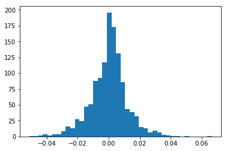

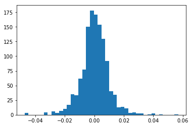

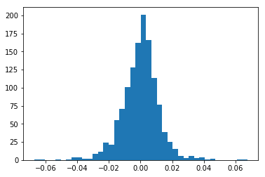

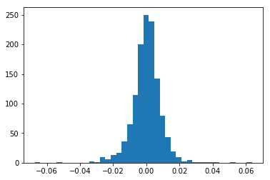

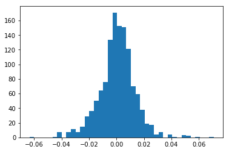

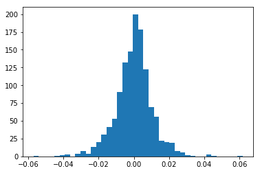

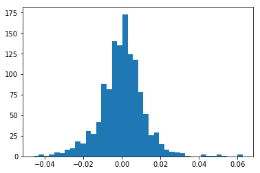

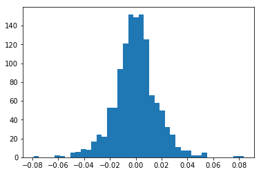

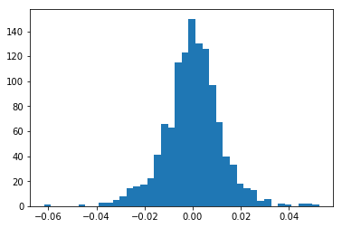

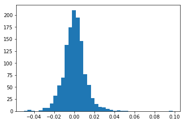

```python
for df in df_list:
    plt.hist(df['Change'], bins=40, range=(df['Change'].min(),df['Change'].max()))
    plt.show()
```

### Machine Learning and Hypothesis Testing

##### In the next step, we will perform multiple regression analysis and hypothesis testing. To create a model in a more efficient way, we will combine all the dataframes for the same date and create a new dataframe, df_merged. Using the statsmodels.api, we will develop a multiple regression analysis model that uses Oil Change%, Gold Change%, T-bonds Change%, USD Index Change%, and EUR Index Change% as explanatory variables and predicts the daily change rate of the S&P 500 sector ETF as the response variable. We will then output a summary report and conduct hypothesis testing while examining the results of the multiple regression analysis. We will start off with xly as a response variable. The null hypothesis is that "there is no slope in the regression line."

```python
from scipy import stats
```

```python
import statsmodels.api as sm
```

```python
df_merged = pd.merge(df_indices, df_xly, on='Date', how='inner')
df_merged = df_merged.drop(['High', 'Low', 'Close', 'Adj Close', 'Volume', 'Open'], axis=1)
df_merged = df_merged.rename(columns={'Change': 'xly'})

df_merged = pd.merge(df_merged, df_xlv, on='Date', how='inner')
df_merged = df_merged.drop(['High', 'Low', 'Close', 'Adj Close', 'Volume', 'Open'], axis=1)
df_merged = df_merged.rename(columns={'Change': 'xlv'})

df_merged = pd.merge(df_merged, df_xlre, on='Date', how='inner')
df_merged = df_merged.drop(['High', 'Low', 'Close', 'Adj Close', 'Volume', 'Open'], axis=1)
df_merged = df_merged.rename(columns={'Change': 'xlre'})

df_merged = pd.merge(df_merged, df_xlp, on='Date', how='inner')
df_merged = df_merged.drop(['High', 'Low', 'Close', 'Adj Close', 'Volume', 'Open'], axis=1)
df_merged = df_merged.rename(columns={'Change': 'xlp'})

df_merged = pd.merge(df_merged, df_xlk, on='Date', how='inner')
df_merged = df_merged.drop(['High', 'Low', 'Close', 'Adj Close', 'Volume', 'Open'], axis=1)
df_merged = df_merged.rename(columns={'Change': 'xlk'})

df_merged = pd.merge(df_merged, df_xli, on='Date', how='inner')
df_merged = df_merged.drop(['High', 'Low', 'Close', 'Adj Close', 'Volume', 'Open'], axis=1)
df_merged = df_merged.rename(columns={'Change': 'xli'})

df_merged = pd.merge(df_merged, df_xlf, on='Date', how='inner')
df_merged = df_merged.drop(['High', 'Low', 'Close', 'Adj Close', 'Volume', 'Open'], axis=1)
df_merged = df_merged.rename(columns={'Change': 'xlf'})

df_merged = pd.merge(df_merged, df_xle, on='Date', how='inner')
df_merged = df_merged.drop(['High', 'Low', 'Close', 'Adj Close', 'Volume', 'Open'], axis=1)
df_merged = df_merged.rename(columns={'Change': 'xle'})

df_merged = pd.merge(df_merged, df_xlc, on='Date', how='inner')
df_merged = df_merged.drop(['High', 'Low', 'Close', 'Adj Close', 'Volume', 'Open'], axis=1)
df_merged = df_merged.rename(columns={'Change': 'xlc'})

df_merged = pd.merge(df_merged, df_xlb, on='Date', how='inner')
df_merged = df_merged.drop(['Date','High', 'Low', 'Close', 'Adj Close', 'Volume', 'Open'], axis=1)
df_merged = df_merged.rename(columns={'Change': 'xlb'})
```

```python
df_merged
```

|  | Oil Change % | Gold Change % | T-bonds Change % | USD Index Change % | EUR Index Change % | xly | xlv | xlre | xlp | xlk | xli | xlf | xle | xlc | xlb |
| --- | --- | --- | --- | --- | --- | --- | --- | --- | --- | --- | --- | --- | --- | --- | --- |
| 0 | 0.0175 | -0.0062 | -0.0208 | 0.0036 | 0.0068 | 0.020194 | 0.007314 | 0.017420 | 0.002953 | 0.015535 | 0.007267 | 0.005316 | 0.004365 | 0.017018 | 0.016125 |
| 1 | 0.0192 | 0.0083 | -0.0053 | -0.0047 | 0.0010 | -0.000823 | 0.000000 | 0.002192 | 0.000270 | 0.002356 | -0.002796 | -0.009346 | -0.003875 | 0.002467 | -0.003515 |
| 2 | -0.0031 | -0.0049 | -0.0016 | 0.0019 | -0.0001 | 0.008028 | -0.002193 | 0.013756 | 0.000000 | 0.008290 | 0.005449 | 0.003780 | 0.003923 | 0.003901 | 0.001016 |
| 3 | 0.0054 | 0.0088 | 0.0091 | -0.0040 | 0.0000 | -0.000917 | -0.005012 | 0.004557 | 0.000272 | -0.002974 | 0.007075 | 0.000956 | 0.021239 | -0.006226 | 0.004911 |
| 4 | 0.0513 | -0.0104 | 0.0495 | -0.0024 | 0.0004 | -0.007486 | -0.002964 | -0.009516 | 0.001912 | -0.009235 | 0.000307 | -0.003173 | 0.010672 | -0.005649 | -0.002964 |
| ... | ... | ... | ... | ... | ... | ... | ... | ... | ... | ... | ... | ... | ... | ... | ... |
| 1117 | 0.0360 | -0.0055 | -0.0019 | 0.0042 | 0.0003 | 0.003385 | -0.003918 | 0.004029 | -0.004432 | 0.000863 | -0.000694 | -0.004104 | 0.010023 | -0.003781 | 0.002079 |
| 1118 | -0.0073 | -0.0026 | -0.0044 | -0.0025 | -0.0004 | -0.017680 | -0.005437 | -0.003093 | 0.007377 | -0.012815 | -0.004858 | -0.006308 | -0.017216 | -0.015529 | -0.010647 |
| 1119 | 0.0464 | 0.0016 | -0.0013 | -0.0024 | 0.0033 | -0.006071 | 0.000825 | 0.005289 | 0.005845 | -0.005758 | -0.003568 | -0.011683 | -0.004636 | -0.001977 | 0.007056 |
| 1120 | -0.0103 | -0.0007 | -0.0131 | -0.0033 | 0.0000 | -0.008536 | -0.004826 | 0.005020 | 0.000586 | -0.011550 | -0.008903 | 0.000368 | -0.011537 | -0.009848 | -0.008253 |
| 1121 | 0.0177 | -0.0052 | 0.0139 | -0.0000 | 0.0003 | -0.000445 | 0.000824 | 0.009512 | -0.001953 | -0.000279 | -0.002722 | -0.011594 | -0.001596 | 0.002577 | -0.007322 |

1122 rows × 15 columns

```python
y = df_merged['xly']
x = df_merged[['Oil Change %','T-bonds Change %',
       'USD Index Change %', 'EUR Index Change %', 'Gold Change %']]
model = sm.OLS(y, sm.add_constant(x))
result = model.fit()
result.summary()
```

OLS Regression Results

| Dep. Variable: | xly | R-squared: | 0.026 |
| --- | --- | --- | --- |
| Model: | OLS | Adj. R-squared: | 0.021 |
| Method: | Least Squares | F-statistic: | 5.898 |
| Date: | Fri, 12 May 2023 | Prob (F-statistic): | 2.17e-05 |
| Time: | 02:22:04 | Log-Likelihood: | 3398.2 |
| No. Observations: | 1122 | AIC: | -6784. |
| Df Residuals: | 1116 | BIC: | -6754. |
| Df Model: | 5 |  |  |
| Covariance Type: | nonrobust |  |  |

|  | coef | std err | t | P>\|t\| | [0.025 | 0.975] |
| --- | --- | --- | --- | --- | --- | --- |
| const | -0.0003 | 0.000 | -0.811 | 0.418 | -0.001 | 0.000 |
| Oil Change % | 0.0147 | 0.012 | 1.225 | 0.221 | -0.009 | 0.038 |
| T-bonds Change % | 0.0360 | 0.013 | 2.711 | 0.007 | 0.010 | 0.062 |
| USD Index Change % | -0.3807 | 0.103 | -3.694 | 0.000 | -0.583 | -0.178 |
| EUR Index Change % | 0.2355 | 0.213 | 1.107 | 0.269 | -0.182 | 0.653 |
| Gold Change % | -0.0244 | 0.053 | -0.464 | 0.643 | -0.128 | 0.079 |

| Omnibus: | 75.817 | Durbin-Watson: | 2.087 |
| --- | --- | --- | --- |
| Prob(Omnibus): | 0.000 | Jarque-Bera (JB): | 326.116 |
| Skew: | -0.095 | Prob(JB): | 1.53e-71 |
| Kurtosis: | 5.634 | Cond. No. | 608. |

Notes:  
[1] Standard Errors assume that the covariance matrix of the errors is correctly specified.

```python
for pvalue in result.pvalues:
    print(pvalue)
```

```
0.4175003390395816
0.22094423045427344
0.006819113942792864
0.00023178675149262577
0.26857436913646054
0.6430882779543599
```

```python
y = df_merged['xlv']
x = df_merged[['Oil Change %','T-bonds Change %',
       'USD Index Change %', 'EUR Index Change %', 'Gold Change %']]
model = sm.OLS(y, sm.add_constant(x))
result = model.fit()
result.summary()
```

OLS Regression Results

| Dep. Variable: | xlv | R-squared: | 0.033 |
| --- | --- | --- | --- |
| Model: | OLS | Adj. R-squared: | 0.028 |
| Method: | Least Squares | F-statistic: | 7.522 |
| Date: | Thu, 11 May 2023 | Prob (F-statistic): | 5.88e-07 |
| Time: | 07:32:26 | Log-Likelihood: | 3725.3 |
| No. Observations: | 1122 | AIC: | -7439. |
| Df Residuals: | 1116 | BIC: | -7408. |
| Df Model: | 5 |  |  |
| Covariance Type: | nonrobust |  |  |

|  | coef | std err | t | P>\|t\| | [0.025 | 0.975] |
| --- | --- | --- | --- | --- | --- | --- |
| const | -6.513e-05 | 0.000 | -0.244 | 0.808 | -0.001 | 0.000 |
| Oil Change % | 0.0299 | 0.009 | 3.343 | 0.001 | 0.012 | 0.047 |
| T-bonds Change % | 0.0346 | 0.010 | 3.482 | 0.001 | 0.015 | 0.054 |
| USD Index Change % | -0.1551 | 0.077 | -2.014 | 0.044 | -0.306 | -0.004 |
| EUR Index Change % | 0.1958 | 0.159 | 1.232 | 0.218 | -0.116 | 0.508 |
| Gold Change % | 0.0334 | 0.039 | 0.848 | 0.397 | -0.044 | 0.111 |

| Omnibus: | 64.053 | Durbin-Watson: | 1.992 |
| --- | --- | --- | --- |
| Prob(Omnibus): | 0.000 | Jarque-Bera (JB): | 243.207 |
| Skew: | -0.034 | Prob(JB): | 1.54e-53 |
| Kurtosis: | 5.280 | Cond. No. | 608. |

Notes:  
[1] Standard Errors assume that the covariance matrix of the errors is correctly specified.

```python
y = df_merged['xlre']
x = df_merged[['Oil Change %','T-bonds Change %',
       'USD Index Change %', 'EUR Index Change %', 'Gold Change %']]
model = sm.OLS(y, sm.add_constant(x))
result = model.fit()
result.summary()
```

OLS Regression Results

| Dep. Variable: | xlre | R-squared: | 0.020 |
| --- | --- | --- | --- |
| Model: | OLS | Adj. R-squared: | 0.016 |
| Method: | Least Squares | F-statistic: | 4.606 |
| Date: | Thu, 11 May 2023 | Prob (F-statistic): | 0.000365 |
| Time: | 07:32:35 | Log-Likelihood: | 3463.6 |
| No. Observations: | 1122 | AIC: | -6915. |
| Df Residuals: | 1116 | BIC: | -6885. |
| Df Model: | 5 |  |  |
| Covariance Type: | nonrobust |  |  |

|  | coef | std err | t | P>\|t\| | [0.025 | 0.975] |
| --- | --- | --- | --- | --- | --- | --- |
| const | -0.0002 | 0.000 | -0.647 | 0.518 | -0.001 | 0.000 |
| Oil Change % | 0.0065 | 0.011 | 0.578 | 0.563 | -0.016 | 0.029 |
| T-bonds Change % | -0.0024 | 0.013 | -0.195 | 0.845 | -0.027 | 0.022 |
| USD Index Change % | -0.2970 | 0.097 | -3.055 | 0.002 | -0.488 | -0.106 |
| EUR Index Change % | 0.0802 | 0.201 | 0.400 | 0.689 | -0.314 | 0.474 |
| Gold Change % | 0.0721 | 0.050 | 1.449 | 0.148 | -0.026 | 0.170 |

| Omnibus: | 68.947 | Durbin-Watson: | 2.091 |
| --- | --- | --- | --- |
| Prob(Omnibus): | 0.000 | Jarque-Bera (JB): | 270.911 |
| Skew: | -0.091 | Prob(JB): | 1.49e-59 |
| Kurtosis: | 5.400 | Cond. No. | 608. |

Notes:  
[1] Standard Errors assume that the covariance matrix of the errors is correctly specified.

##### The current situation is a little pity, so let's try rebuilding the model by using the nine other sector ETFs

```python
y = df_merged['xly']
x = df_merged[['Oil Change %','T-bonds Change %',
       'USD Index Change %', 'EUR Index Change %', 'Gold Change %', 'xlv', 'xlre', 'xlp',
       'xlk', 'xli', 'xlf', 'xle', 'xlc', 'xlb']]
model = sm.OLS(y, sm.add_constant(x))
result = model.fit()
result.summary()
```

OLS Regression Results

| Dep. Variable: | xly | R-squared: | 0.793 |
| --- | --- | --- | --- |
| Model: | OLS | Adj. R-squared: | 0.790 |
| Method: | Least Squares | F-statistic: | 302.8 |
| Date: | Thu, 11 May 2023 | Prob (F-statistic): | 0.00 |
| Time: | 07:43:59 | Log-Likelihood: | 4267.0 |
| No. Observations: | 1122 | AIC: | -8504. |
| Df Residuals: | 1107 | BIC: | -8429. |
| Df Model: | 14 |  |  |
| Covariance Type: | nonrobust |  |  |

|  | coef | std err | t | P>\|t\| | [0.025 | 0.975] |
| --- | --- | --- | --- | --- | --- | --- |
| const | -0.0002 | 0.000 | -1.392 | 0.164 | -0.001 | 9.49e-05 |
| Oil Change % | -0.0116 | 0.006 | -2.025 | 0.043 | -0.023 | -0.000 |
| T-bonds Change % | -0.0078 | 0.006 | -1.236 | 0.217 | -0.020 | 0.005 |
| USD Index Change % | -0.0628 | 0.048 | -1.299 | 0.194 | -0.158 | 0.032 |
| EUR Index Change % | -0.0135 | 0.099 | -0.137 | 0.891 | -0.207 | 0.180 |
| Gold Change % | -0.0518 | 0.025 | -2.109 | 0.035 | -0.100 | -0.004 |
| xlv | -0.0868 | 0.029 | -2.965 | 0.003 | -0.144 | -0.029 |
| xlre | 0.0809 | 0.021 | 3.892 | 0.000 | 0.040 | 0.122 |
| xlp | -0.0585 | 0.030 | -1.930 | 0.054 | -0.118 | 0.001 |
| xlk | 0.4477 | 0.027 | 16.757 | 0.000 | 0.395 | 0.500 |
| xli | 0.1975 | 0.038 | 5.203 | 0.000 | 0.123 | 0.272 |
| xlf | 0.0652 | 0.028 | 2.357 | 0.019 | 0.011 | 0.119 |
| xle | -0.0455 | 0.014 | -3.308 | 0.001 | -0.072 | -0.019 |
| xlc | 0.2770 | 0.028 | 9.790 | 0.000 | 0.221 | 0.333 |
| xlb | 0.1031 | 0.031 | 3.354 | 0.001 | 0.043 | 0.163 |

| Omnibus: | 11.935 | Durbin-Watson: | 2.020 |
| --- | --- | --- | --- |
| Prob(Omnibus): | 0.003 | Jarque-Bera (JB): | 17.738 |
| Skew: | -0.060 | Prob(JB): | 0.000141 |
| Kurtosis: | 3.604 | Cond. No. | 611. |

Notes:  
[1] Standard Errors assume that the covariance matrix of the errors is correctly specified.

##### We used xly (Consumer Discretionary Select Sector) as the response variable and obtained what appears to be an ideal model. However, since the demand and supply of stocks are generally influenced by other stocks, this is a natural result. We can try to improve the model by removing explanatory variables with p-values higher than the significance level. These variables are EUR Index Change %, USD Index Change %, T-bonds Index Change %, and xlp. What's interesting is that the model shows that the change rates of gold and oil are functioning as explanatory variables. This could be explained by the fact that gold is often considered a safe-haven asset that attracts demand during market downturns. The Consumer Discretionary Select Sector comprises service companies such as automobiles, apparel, hotels, and restaurants, which are correlated with economic prosperity. Therefore, it makes sense that the coefficient for gold is negative when xly is used as the response variable.